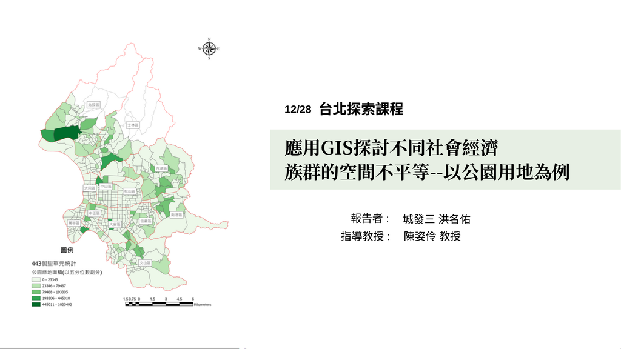

台

北

探

索

課

程

城

發

三

洪

名

佑

陳

姿

伶

教

授

12/28

報

告

者

:

指

導

教

授

:

應

⽤

GIS

探

討

不

同

社

會

經

濟

族

群

的

空

間

不

平

等

--

以

公

園

⽤

地

為

例

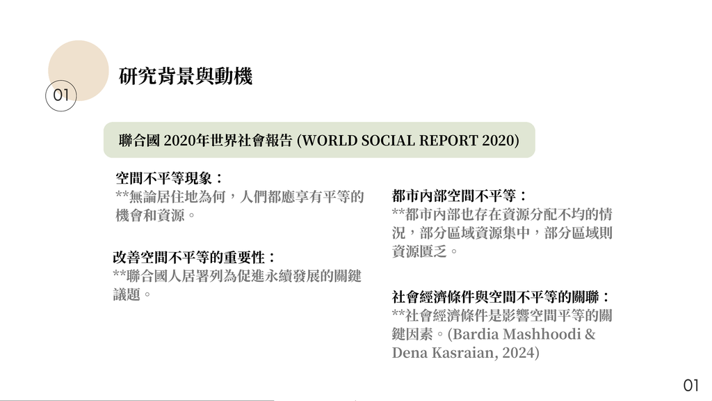

研

究

背

景

與

動

機

社

會

經

濟

條

件

與

空

間

不

平

等

的

關

聯

：

社

會

經

濟

條

件

是

影

響

空

間

平

等

的

關

鍵

因

素

。

(Bardia Mashhoodi &

Dena Kasraian, 2024)

空

間

不

平

等

現

象

：

無

論

居

住

地

為

何

，

⼈

們

都

應

享

有

平

等

的

機

會

和

資

源

。

都

市

內

部

空

間

不

平

等

：

都

市

內

部

也

存

在

資

源

分

配

不

均

的

情

況

，

部

分

區

域

資

源

集

中

，

部

分

區

域

則

資

源

匱

乏

。

改

善

空

間

不

平

等

的

重

要

性

：

聯

合

國

⼈

居

署

列

為

促

進

永

續

發

展

的

關

鍵

議

題

。

聯

合

國

2020

年

世

界

社

會

報

告

(WORLD SOCIAL REPORT 2020)

01

01

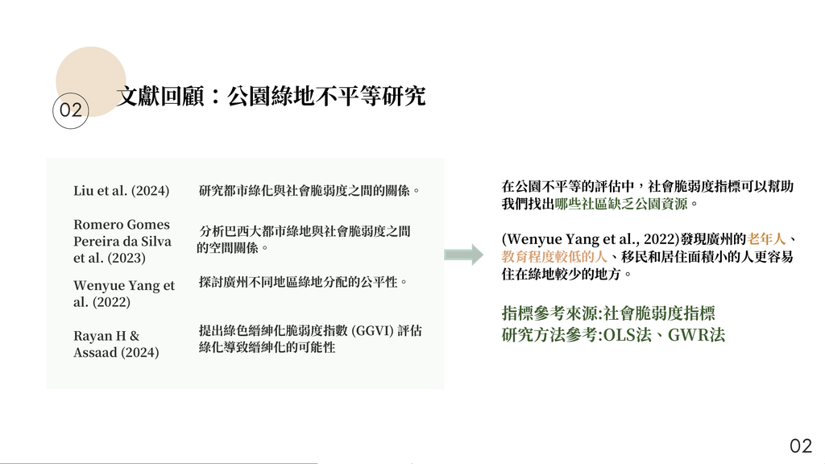

⽂

獻

回

顧

：

公

園

綠

地

不

平

等

研

究

02

提

出

綠

⾊

縉

紳

化

脆

弱

度

指

數

(GGVI)

評

估

綠

化

導

致

縉

紳

化

的

可

能

性

Liu et al. (2024)

研

究

都

市

綠

化

與

社

會

脆

弱

度

之

間

的

關

係

。

Romero Gomes

Pereira da Silva

et al. (2023)

分

析

巴

西

⼤

都

市

綠

地

與

社

會

脆

弱

度

之

間

的

空

間關

係

。

Wenyue Yang et

al. (2022)

探

討

廣

州

不

同

地

區

綠

地

分

配

的

公

平

性

。

Rayan H &

Assaad (2024)

在

公

園

不

平

等

的

評

估

中

，

社

會

脆

弱

度

指

標

可

以

幫

助

我

們

找

出

哪

些

社

區

缺

乏

公

園

資

源

。

(Wenyue Yang et al., 2022)

發

現

廣

州

的

老

年

⼈

、

教

育

程

度

較

低

的

⼈

、

移

⺠

和

居

住

⾯

積

小

的

⼈

更

容

易

住

在

綠

地

較

少

的

地

⽅

。

指

標

參

考

來

源

:

社

會

脆

弱

度

指

標

研

究

⽅

法

參

考

:OLS

法

、

GWR

法

02

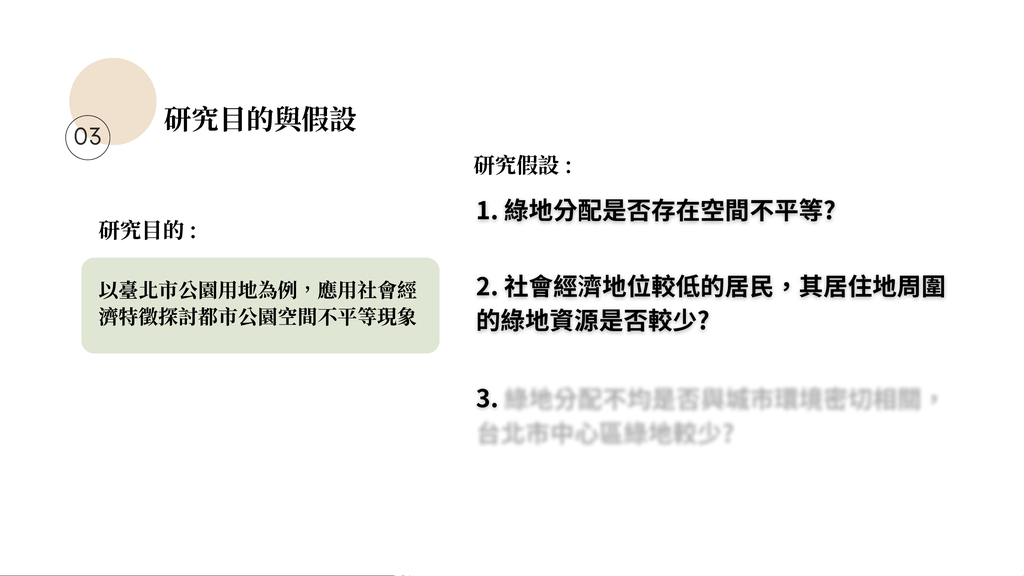

研

究

⽬的

與

假

設

03

以

臺

北

市

公

園

⽤

地

為

例

，

應

⽤

社

會

經

濟

特

徵

探

討

都

市

公

園

空

間

不

平

等

現

象

研

究

⽬的

:

研

究

假

設

:

2. 社會經濟地位較低的居⺠，其居住地周圍

的綠地資源是否較少?

1. 綠地分配是否存在空間不平等?

3. 綠地分配不均是否與城市環境密切相關，

台北市中⼼區綠地較少?

03

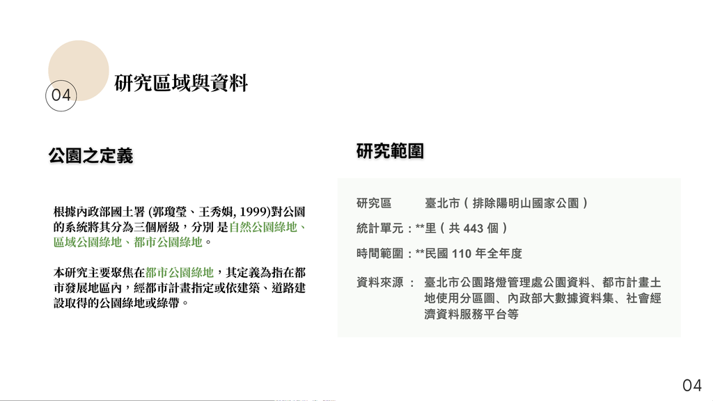

研

究

區

域

與

資

料

04

研究範圍

研究區域：**臺北市（排除陽明山國家公園）

統計單元：**里（共 443 個）

時間範圍：**民國 110 年全年度

資料來源 : 臺北市公園路燈管理處公園資料、都市計畫土

地使用分區圖、內政部大數據資料集、社會經

濟資料服務平台等

公園之定義

根

據

內

政

部

國⼟

署

(

郭

瓊

瑩

、

王

秀

娟

, 1999)

對

公

園

的

系

統

將

其

分

為

三

個

層

級

，

分別

是

⾃

然

公

園

綠

地

、

區

域

公

園

綠

地

、

都

市

公

園

綠

地

。

本

研

究

主

要

聚

焦

在

都

市

公

園

綠

地

，

其

定

義

為

指

在

都

市

發

展

地

區

內

，

經

都

市

計

畫

指

定

或

依

建

築

、

道

路

建

設

取

得

的

公

園

綠

地

或

綠

帶

。

04

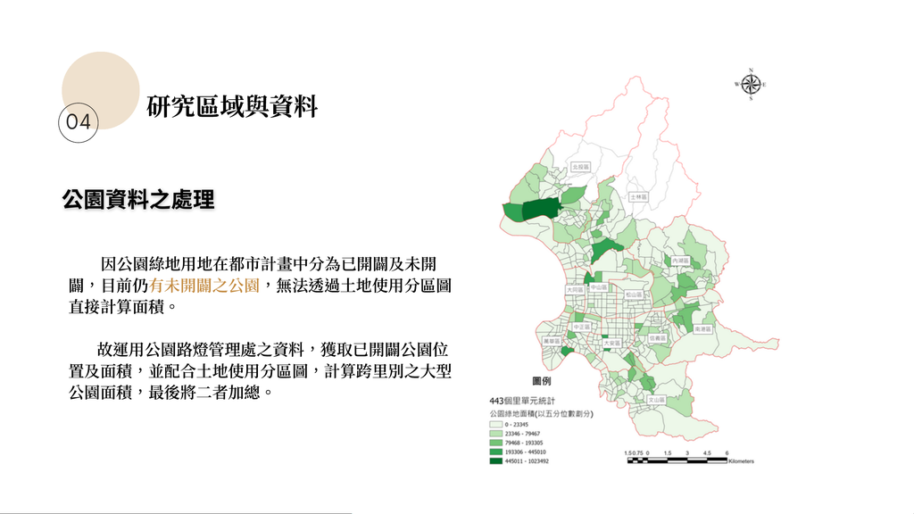

研

究

區

域

與

資

料

04

公園資料之處理

因

公

園

綠

地

⽤

地在

都

市

計

畫

中

分

為

已

開闢

及

未

開

闢

，

⽬

前

仍

有

未

開闢

之

公

園

，

無

法

透

過

⼟地

使

⽤

分

區

圖

直

接

計

算

⾯

積

。

故

運

⽤

公

園

路

燈

管

理

處

之

資

料

，

獲

取

已

開闢

公

園

位

置

及

⾯

積

，

並

配

合

⼟地

使

⽤

分

區

圖

，

計

算

跨

⾥

別

之

⼤

型

公

園

⾯

積

，

最

後

將

⼆

者

加

總

。

05

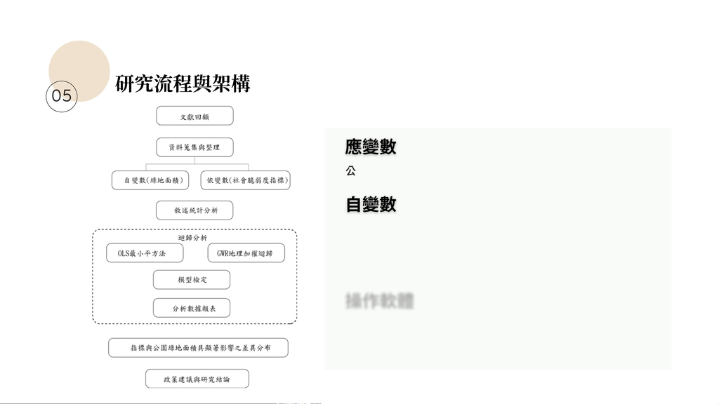

操作軟體

研

究

流

程

與

架

構

05

應變數

⾃變數

公園綠地用地，於GIS軟體上進行面積加總計算

參考各項社會脆弱指標，包含年齡層、教育程度、

家戶狀況、居住狀況、社會經濟狀況等，預期目的

為可看出與公園綠地分配不均的關聯

EXCEL、QGIS、ARCGIS

06

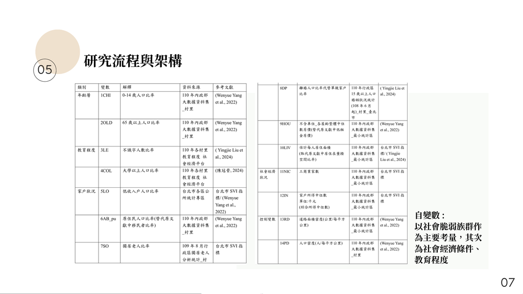

研

究

流

程

與

架

構

05

⾃

變

數

:

以

社

會

脆

弱

族

群

作

為

主

要

考

量

，

其

次

為

社

會

經

濟

條

件

、

教

育

程

度

07

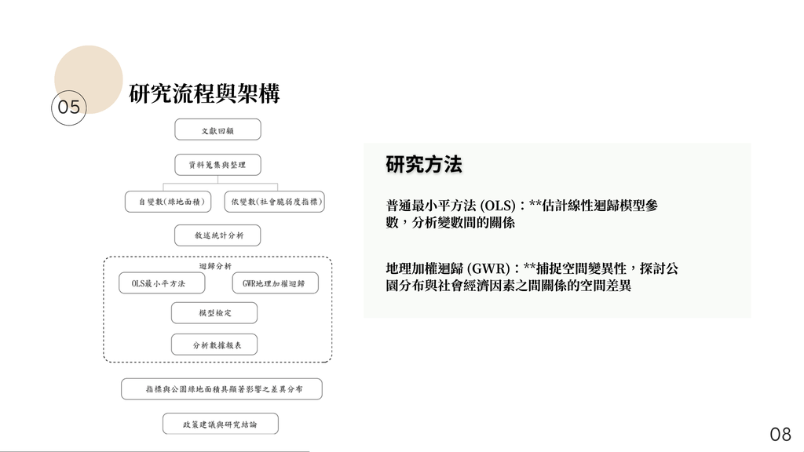

研

究

流

程

與

架

構

05

研究⽅法

普

通

最

小

平

⽅

法

(OLS)

：

估

計

線

性

迴

歸

模

型

參

數

，

分

析

變

數

間

的

關

係

地

理

加

權

迴

歸

(GWR)

：

捕捉

空

間

變

異

性

，

探

討

公

園

分

布

與

社

會

經

濟

因

素

之

間關

係

的

空

間

差

異

08

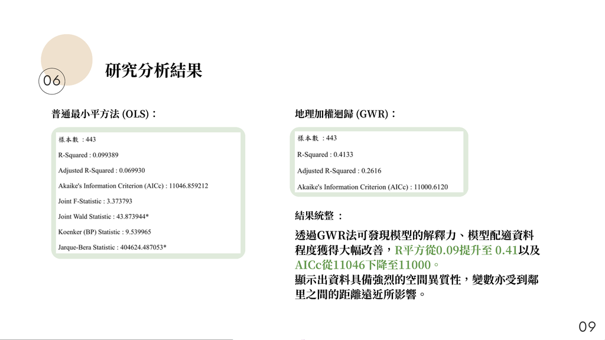

研

究

分

析

結

果

06

普

通

最

小

平

⽅

法

(OLS)

：

地

理

加

權

迴

歸

(GWR)

：

結

果

統

整

:

透

過

GWR

法

可

發

現

模

型

的

解

釋

⼒

、

模

型

配

適

資

料

程

度

獲

得

⼤

幅

改

善

，

R

平

⽅

從

0.09

提

升

⾄

0.41

以

及

AICc

從

11046

下

降

⾄

11000

。

顯

示

出

資

料

具

備

強

烈

的

空

間

異

質

性

，

變

數

亦

受

到

鄰

⾥

之

間

的

距

離

遠

近

所

影

響

。

09

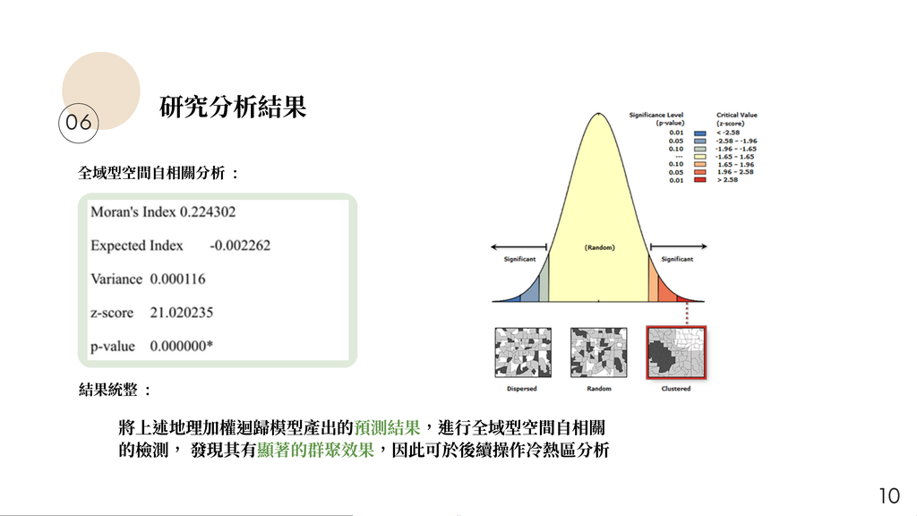

研

究

分

析

結

果

06

全

域

型

空

間

⾃

相

關

分

析

:

結

果

統

整

:

將

上

述

地

理

加

權

迴

歸

模

型

產

出

的

預

測

結

果

，

進

⾏

全

域

型

空

間

⾃

相

關

的

檢

測

，

發

現

其

有

顯

著

的

群

聚

效

果

，

因

此

可

於

後

續

操

作

冷

熱

區

分

析

10

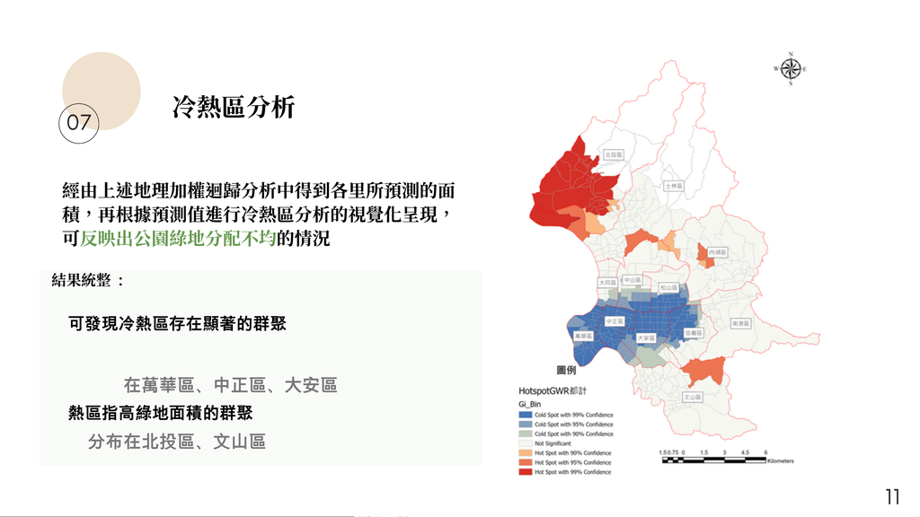

冷

熱

區

分

析

07

結

果

統

整

:

可發現冷熱區存在顯著的群聚。

經

由

上

述

地

理

加

權

迴

歸

分

析

中

得

到

各

⾥

所

預

測

的

⾯

積

，

再

根

據

預

測

值

進

⾏

冷

熱

區

分

析

的

視

覺

化

呈

現

，

可

反

映

出

公

園

綠

地

分

配

不

均

的

情

況

冷區指低綠地面積的群聚

分布在萬華區、中正區、大安區

分布在北投區、文山區

熱區指高綠地面積的群聚

11

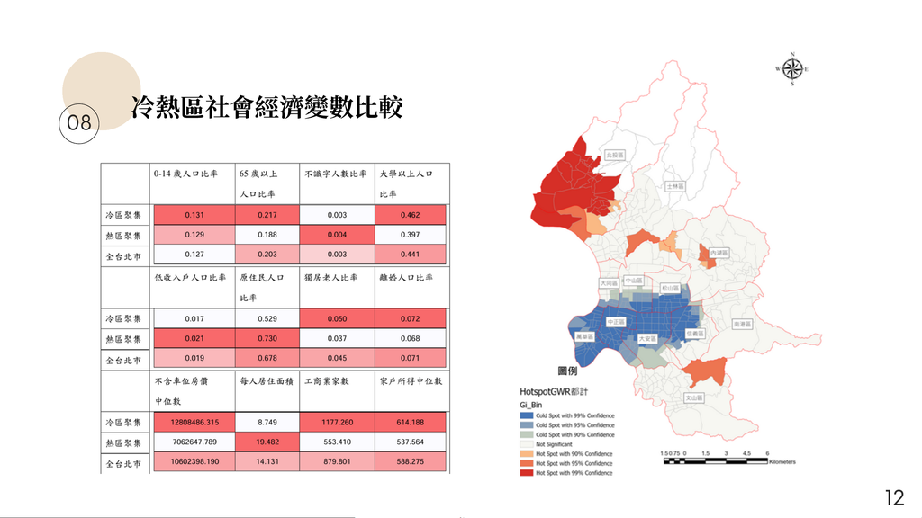

冷

熱

區

社

會

經

濟

變

數

比

較

08

12

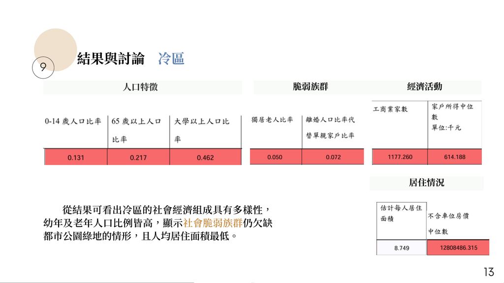

結

果

與

討

論

冷

區

9

從

結

果

可

看

出冷

區

的

社

會

經

濟

組

成

具

有

多

樣

性

，

幼年

及

老

年

⼈

口

比

例

皆

⾼

，

顯

示

社

會

脆

弱

族

群

仍

⽋

缺

都

市

公

園

綠

地

的

情

形

，

且

⼈

均

居

住

⾯

積

最

低

。

⼈

口

特

徵

脆

弱

族

群

經

濟

活

動

居

住

情

況

13

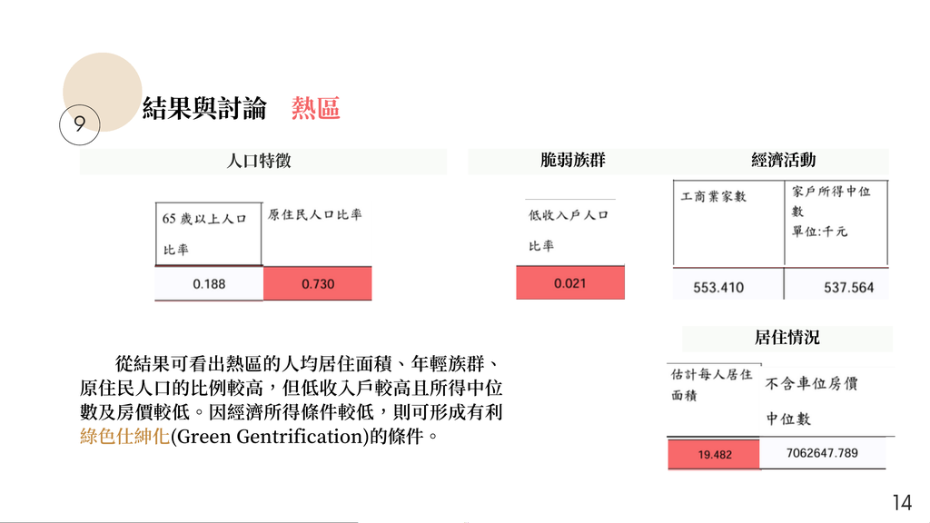

結

果

與

討

論

熱

區

9

從

結

果

可

看

出

熱

區

的

⼈

均

居

住

⾯

積

、

年

輕

族

群

、

原

住

⺠

⼈

口

的

比

例

較

⾼

，

但低

收

入

戶

較

⾼

且

所

得

中

位

數

及

房

價

較

低

。

因

經

濟

所

得

條

件

較

低

，

則

可

形

成

有

利

綠

⾊

仕

紳

化

(Green Gentrification)

的

條

件

。

⼈

口

特

徵

脆

弱

族

群

經

濟

活

動

居

住

情

況

14

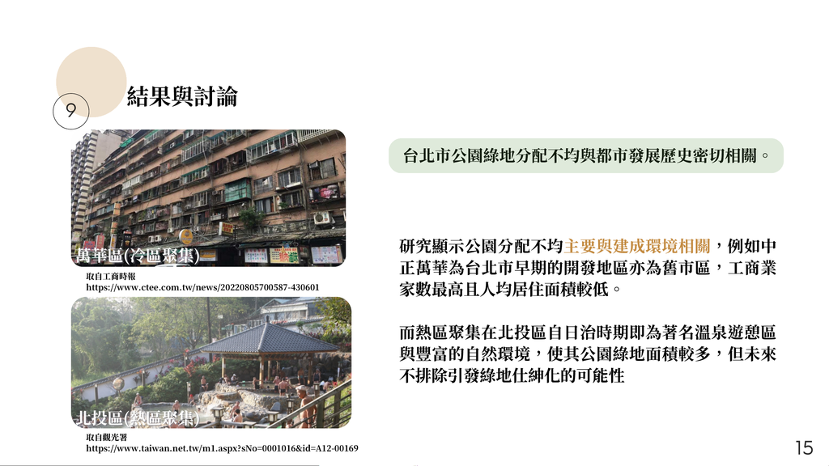

萬

華

區

(

冷

區

聚

集

)

萬

華

區

(

冷

區

聚

集

)

萬

華

區

(

冷

區

聚

集

)

北

投

區

(

熱

區

聚

集

)

北

投

區

(

熱

區

聚

集

)

北

投

區

(

熱

區

聚

集

)

取

⾃

⼯

商

時

報

https://www.ctee.com.tw/news/20220805700587-430601

取

⾃

觀

光

署

https://www.taiwan.net.tw/m1.aspx?sNo=0001016&id=A12-00169

研

究

顯

示

公

園

分

配

不

均

主

要

與

建

成

環

境

相

關

，

例

如

中

正

萬

華

為

台

北

市

早

期

的

開

發

地

區

亦

為

舊

市

區

，

⼯

商

業

家

數

最

⾼

且

⼈

均

居

住

⾯

積

較

低

。

而

熱

區

聚

集

在

北

投

區

⾃

⽇

治

時

期

即

為

著

名

溫

泉

遊

憩

區

與

豐

富

的

⾃

然

環

境

，

使

其公

園

綠

地

⾯

積

較

多

，

但

未

來

不

排

除

引

發

綠

地

仕

紳

化

的

可

能

性

台

北

市

公

園

綠

地

分

配

不

均

與

都

市

發

展

歷

史

密

切

相

關

。

結

果

與

討

論

9

15

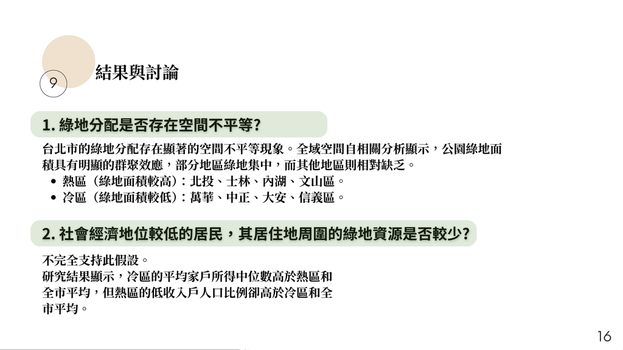

結

果

與

討

論

9

2. 社會經濟地位較低的居⺠，其居住地周圍的綠地資源是否較少?

1. 綠地分配是否存在空間不平等?

不

完

全

⽀

持

此

假

設

。

研

究

結

果

顯

示

，

冷

區

的

平

均

家

戶所

得

中

位

數

⾼

於

熱

區

和

全

市

平

均

，

但

熱

區

的

低

收

入

戶

⼈

口

比

例

卻

⾼

於

冷

區

和

全

市

平

均

。

台

北

市

的

綠

地

分

配

存

在

顯

著

的

空

間

不

平

等

現

象

。

全

域

空

間

⾃

相

關

分

析

顯

示

，

公

園

綠

地

⾯

積

具

有

明

顯

的

群

聚

效

應

，

部

分

地

區

綠

地

集

中

，

而

其

他

地

區

則

相

對

缺

乏

。

熱

區

（

綠

地

⾯

積

較

⾼

）：

北

投

、

⼠

林

、

內

湖

、

⽂

⼭

區

。

冷

區

（

綠

地

⾯

積

較

低

）：

萬

華

、

中

正

、

⼤

安

、

信

義

區

。

16

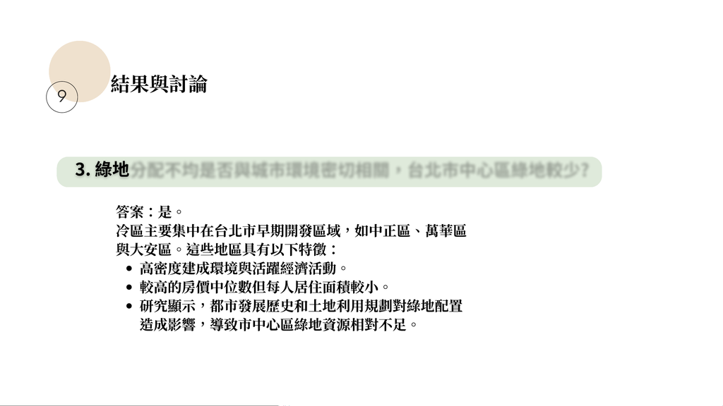

結

果

與

討

論

9

3. 綠地分配不均是否與城市環境密切相關，台北市中⼼區綠地較少?

答

案

：

是

。

冷

區

主

要

集

中

在

台

北

市

早

期

開

發

區

域

，

如

中

正

區

、

萬

華

區

與

⼤

安

區

。

這

些

地

區

具

有

以

下

特

徵

：

⾼

密

度

建

成

環

境

與

活

躍

經

濟

活

動

。

較

⾼

的

房

價

中

位

數

但

每

⼈

居

住

⾯

積

較

小

。

研

究

顯

示

，

都

市

發

展

歷

史

和

⼟地

利

⽤

規

劃

對

綠

地

配

置

造

成

影

響

，

導

致

市

中

⼼

區

綠

地

資

源

相

對

不

⾜

。

17

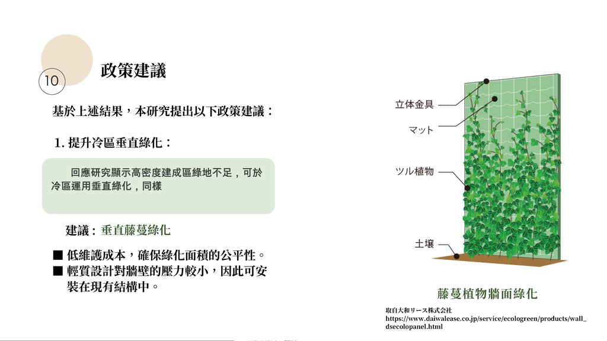

政

策

建

議

10

基

於

上

述

結

果

，

本

研

究

提

出

以

下

政

策

建

議

：

1.

提

升

冷

區

垂

直

綠

化

：

回應研究顯示高密度建成區綠地不足，可於

冷區運用垂直綠化，同樣能達到與公園綠地相同

的益處，如改善空氣及環境品質等作用。

垂

直

藤

蔓

綠

化

■

低

維

護

成

本

，

確

保

綠

化

⾯

積

的

公

平

性

。

■

輕

質

設

計

對

牆

壁

的

壓

⼒

較

小

，

因

此

可

安

裝

在

現

有

結

構

中

。

藤

蔓

植

物牆

⾯

綠

化

建

議

:

取

⾃

⼤

和

リース

株

式

会

社

https://www.daiwalease.co.jp/service/ecologreen/products/wall_

dsecolopanel.html

18

[figure not shown]

政

策

建

議

10

基

於

上

述

結

果

，

本

研

究

提

出

以

下

政

策

建

議

：

2.

優先

關

注

社

會

脆

弱

群

體

：

研究結果，冷區的人口型態以幼年、老人、

獨居者、單親比例較高，涵蓋多樣的族群，需改

善脆弱族群前往公園之可及性。

形

塑

⼈

本

街

道

與

公

園

串

連

■

城

市

規

劃

應

以

與

公

園

串

聯

思

考

■

建

構

友

善

各

族

群

、

無

障

礙

之

街

道

■

老

⼈

活

動

以

可

步

⾏

距

離

300

公

尺

內

配

置

(

张

灵

珠

等

,2020)

如

美

國

的

POPS

私

有

公共

空

間

，

規

範

⼈

⾏

道

和

廣

場

之

間

⾼

度

、

無

障

礙

環

境

等

項

⽬

。

建

議

:

19

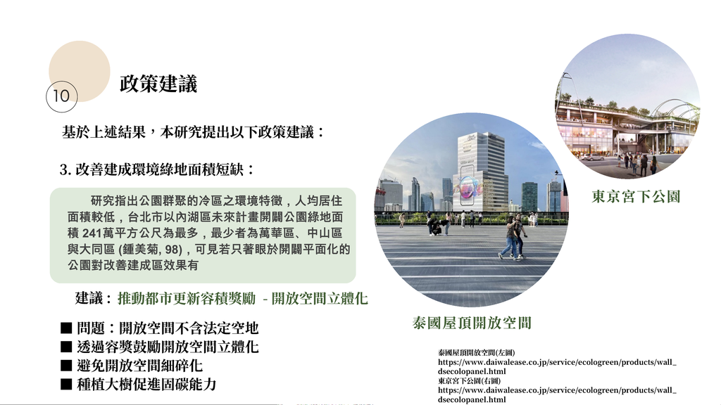

基

於

上

述

結

果

，

本

研

究

提

出

以

下

政

策

建

議

：

推

動

都

市

更

新

容

積

獎

勵

-

開

放

空

間

⽴

體

化

■

問

題

：

開

放

空

間

不

含

法

定

空

地

■

透

過

容

獎

⿎

勵

開

放

空

間

⽴

體

化

■

避

免

開

放

空

間

細

碎

化

■

種

植

⼤

樹

促

進

固

碳

能

⼒

政

策

建

議

10

3.

改

善

建

成

環

境

綠

地

⾯

積

短

缺

：

研究指出公園群聚的冷區之環境特徵，人均居住

面積較低，台北市以內湖區未來計畫開闢公園綠地面

積 241萬平方公尺為最多，最少者為萬華區、中山區

與大同區 (鍾美菊, 98)，可見若只著眼於開闢平面化的

公園對改善建成區效果有限，故須以立體化思考

東

京

宮

下

公

園

建

議

:

泰

國

屋

頂

開

放

空

間

(

左

圖

)

https://www.daiwalease.co.jp/service/ecologreen/products/wall_

dsecolopanel.html

東

京

宮

下

公

園

(

右

圖

)

https://www.daiwalease.co.jp/service/ecologreen/products/wall_

dsecolopanel.html

泰

國

屋

頂

開

放

空

間

20

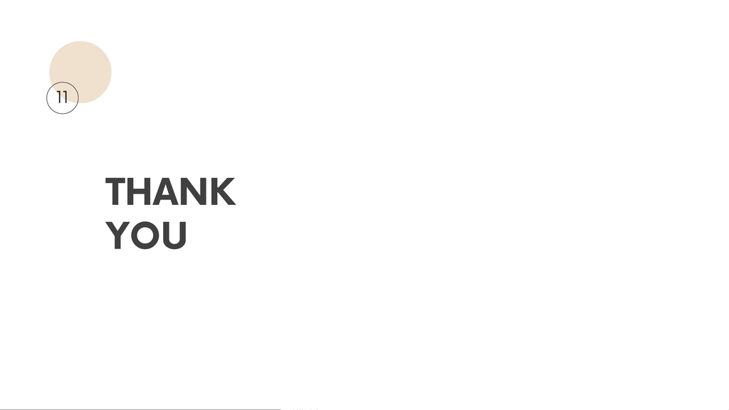

11

THANK

YOU